## Multilevel modeling with R and lme4

The purpose of this document is to explore a few models that attempt to describe how school level variables affect student’s test scores for the 2013 TERCE study.

### Preparing the data

First we need to load the data into R from the SAV files. This dataset contains individual question/answers and we will drop those columns (and a few more) so that we have a new dataframe with only the data that we need.

```r
# load sexto grado puntajes
pm6 <- read.spss('./data/Puntajes_Alumnos/PM6_all_TERCE.sav', to.data.frame=T)
pc6 <- read.spss('./data/Puntajes_Alumnos/PC6_all_TERCE.sav', to.data.frame=T)
pl6 <- read.spss('./data/Puntajes_Alumnos/PL6_all_TERCE.sav', to.data.frame=T)

pm6 <- pm6[,c('idstud',"puntaje_estandar","idschool","country")]
pl6 <- pl6[,c('idstud',"puntaje_estandar","idschool","country")]
pc6 <- pc6[,c('idstud',"puntaje_estandar","idschool","country")]

# merge matematica, lectura y ciencias
pm6$tipo <- 'matematica'
pl6$tipo <- 'lectura'
pc6$tipo <- 'ciencias'
p6 <- rbind.fill(pm6,pl6,pc6)
```

We will also drop anything that is not PANAMA

```r
p6 <- p6[p6$country == 'PAN',]
```

This data has scores for math, science and reading. A single student will be represented by 3 rows in the dataframe. We will average the scores across the three tests for each student so that each student is a single row in the data frame.

```r
p6 <- aggregate(puntaje_estandar ~ idstud + idschool + country , p6, mean)
```

Now we load the data from the schools and make sure R reads them as FACTOR variables for when it is necesary.

```r
# load factores directores (escuelas)
qd <- read.spss('./data/Directores/QD6.SAV', to.data.frame=T)
qd <- qd[qd$country == 'PAN',]

#prep factores
qd$DQDIT14_01 <- as.factor(qd$DQDIT14_01)
qd$DQDIT15_01 <- as.factor(qd$DQDIT15_01)
qd$DQDIT16_01 <- as.factor(qd$DQDIT16_01)
qd$DQDIT16_02 <- as.factor(qd$DQDIT16_02)
qd$DQDIT17_01 <- as.factor(qd$DQDIT17_01)
qd$DQDIT17_01 <- as.factor(qd$DQDIT17_07)
qd$DQDIT17_01 <- as.factor(qd$DQDIT17_09)
qd$DQDIT18_01 <- as.factor(qd$DQDIT18_01)
qd$DQDIT18_02 <- as.factor(qd$DQDIT18_02)
qd$DQDIT18_03 <- as.factor(qd$DQDIT18_03)
qd$DQDIT18_04 <- as.factor(qd$DQDIT18_04)
qd$DQDIT19_01 <- as.factor(qd$DQDIT19_01)
qd$DQDIT21a <- as.factor(qd$DQDIT21a)
qd$DQDIT22_01 <- as.factor(qd$DQDIT22_01)
qd$DQDIT22_02 <- as.factor(qd$DQDIT22_02)
qd$DQDIT23 <- as.factor(qd$DQDIT23)
qd$DQDIT24_02<- as.factor(qd$DQDIT24_02)
qd$DQDIT25_02 <- as.factor(qd$DQDIT25_02)
qd$DQDIT27a <- as.factor(qd$DQDIT27a)
qd$hrsescue <- as.factor(qd$hrsescue)
qd$dependencia <- as.factor(qd$dependencia)
qd$ruralidad <- as.factor(qd$ruralidad)
levels(qd$dependencia) <- c("Oficial","Particular")
levels(qd$ruralidad) <- c("Urbano","Rural")
```

Now we will merge this data to the student score data using the field “idschool”.

```r
pe <- merge(p6,qd,by='idschool')
pe$idschool <- factor(pe$idschool)
pe$idstud <- factor(pe$idstud)
```

Lastly, we need to remove missing data for the columns that we are going to look at

```r
fofit <- na.omit(pe[,c("puntaje_estandar",'idstud','idschool',"dependencia","ruralidad","DQDIT01","DQDIT14_01","DQDIT15_01","DQDIT16_01","DQDIT17_01","DQDIT16_02","DQDIT17_07","DQDIT17_09","DQDIT18_01","DQDIT18_02","DQDIT18_03","DQDIT18_04","DQDIT19_01","DQDIT21a","DQDIT22_01","DQDIT22_02","DQDIT23","DQDIT24_02","DQDIT25_02","DQDIT27a",'INFRAD','VIOLEND','CSOCIALD','AUTOADD','AUTOACD','CLAMBLD','hrsescue')])
```

### Building the models

First we will build the null model with a random effects grouping structure but no fixed predictors, we will compare all other models to this.

```r
fit.lmer_null <- lmer(puntaje_estandar ~ 1 + (1|idschool), data=fofit)
summary(fit.lmer_null)
```

```
## Linear mixed model fit by REML ['lmerMod']
## Formula: puntaje_estandar ~ 1 + (1 | idschool)
##    Data: fofit
##
## REML criterion at convergence: 26015.2
##
## Scaled residuals:
##     Min      1Q  Median      3Q     Max
## -5.5977 -0.6504 -0.0369  0.6111  4.6114
##
## Random effects:
##  Groups   Name        Variance Std.Dev.
##  idschool (Intercept) 2636     51.34
##  Residual             4240     65.11
## Number of obs: 2300, groups:  idschool, 111
##
## Fixed effects:
##             Estimate Std. Error t value
## (Intercept)  679.050      5.093   133.3
```

```r
fit.lmer_null_nest <- lmer(puntaje_estandar ~ 1 + dependencia + ruralidad + (dependencia + ruralidad |idschool), data=fofit)
summary(fit.lmer_null_nest)
```

```
## Linear mixed model fit by REML ['lmerMod']
## Formula: puntaje_estandar ~ 1 + dependencia + ruralidad + (dependencia +
##     ruralidad | idschool)
##    Data: fofit
##
## REML criterion at convergence: 25920.1
##
## Scaled residuals:
##     Min      1Q  Median      3Q     Max
## -5.6175 -0.6390 -0.0426  0.6210  4.5816
##
## Random effects:
##  Groups   Name                  Variance Std.Dev. Corr
##  idschool (Intercept)            539.7   23.23
##           dependenciaParticular 1400.7   37.43    -0.47
##           ruralidadRural        1117.3   33.43    -0.17 -0.79
##  Residual                       4240.2   65.12
## Number of obs: 2300, groups:  idschool, 111
##
## Fixed effects:
##                       Estimate Std. Error t value
## (Intercept)            670.049      6.190  108.25
## dependenciaParticular   74.102      8.498    8.72
## ruralidadRural         -16.048      7.535   -2.13
##
## Correlation of Fixed Effects:
##             (Intr) dpndnP
## dpndncPrtcl -0.632
## ruraliddRrl -0.767  0.433
```

Lets compare the two real quick….

```r
anova(fit.lmer_null,fit.lmer_null_nest)
```

```
## Data: fofit
## Models:
## fit.lmer_null: puntaje_estandar ~ 1 + (1 | idschool)
## fit.lmer_null_nest: puntaje_estandar ~ 1 + dependencia + ruralidad + (dependencia +
## fit.lmer_null_nest:     ruralidad | idschool)
##                    Df   AIC   BIC logLik deviance  Chisq Chi Df Pr(>Chisq)
## fit.lmer_null       3 26026 26044 -13010    26020
## fit.lmer_null_nest 10 25956 26014 -12968    25936 84.154      7  1.953e-15
##
## fit.lmer_null
## fit.lmer_null_nest ***
## ---
## Signif. codes:  0 '***' 0.001 '**' 0.01 '*' 0.05 '.' 0.1 ' ' 1
```

Next we will build a model using the INFRAD as a fixed-effect predictor. We choose to test this variable first because it is tightly related to the socioeconomic factor.

```r
fit.lmer_infrad <- lmer(puntaje_estandar ~ INFRAD + (1|idschool), data=fofit)
summary(fit.lmer_infrad)
```

```
## Linear mixed model fit by REML ['lmerMod']
## Formula: puntaje_estandar ~ INFRAD + (1 | idschool)
##    Data: fofit
##
## REML criterion at convergence: 25923.6
##
## Scaled residuals:
##     Min      1Q  Median      3Q     Max
## -5.5911 -0.6362 -0.0459  0.6209  4.6764
##
## Random effects:
##  Groups   Name        Variance Std.Dev.
##  idschool (Intercept) 1070     32.71
##  Residual             4240     65.12
## Number of obs: 2300, groups:  idschool, 111
##
## Fixed effects:
##             Estimate Std. Error t value
## (Intercept)  668.471      3.571  187.19
## INFRAD        41.024      3.556   11.53
##
## Correlation of Fixed Effects:
##        (Intr)
## INFRAD -0.276
```

Lets look at a model with more predictors

```r
fit.lmer_full_fact <- lmer(puntaje_estandar ~ dependencia + ruralidad + DQDIT01 + DQDIT14_01 + DQDIT15_01 + DQDIT16_01 + DQDIT17_01 + DQDIT18_01 + DQDIT18_02 + DQDIT18_03 + DQDIT18_04 + DQDIT19_01 + DQDIT21a + DQDIT27a + DQDIT16_02 + DQDIT17_07 + DQDIT17_09 + DQDIT23 + DQDIT22_01 + DQDIT22_02 + DQDIT27a + INFRAD + VIOLEND + CSOCIALD + AUTOADD + AUTOACD + CLAMBLD + hrsescue + (1|idschool), data=fofit)
summary(fit.lmer_full_fact)
```

```
## Linear mixed model fit by REML ['lmerMod']
## Formula:
## puntaje_estandar ~ dependencia + ruralidad + DQDIT01 + DQDIT14_01 +
##     DQDIT15_01 + DQDIT16_01 + DQDIT17_01 + DQDIT18_01 + DQDIT18_02 +
##     DQDIT18_03 + DQDIT18_04 + DQDIT19_01 + DQDIT21a + DQDIT27a +
##     DQDIT16_02 + DQDIT17_07 + DQDIT17_09 + DQDIT23 + DQDIT22_01 +
##     DQDIT22_02 + DQDIT27a + INFRAD + VIOLEND + CSOCIALD + AUTOADD +
##     AUTOACD + CLAMBLD + hrsescue + (1 | idschool)
##    Data: fofit
##
## REML criterion at convergence: 25634.6
##
## Scaled residuals:
##     Min      1Q  Median      3Q     Max
## -5.5687 -0.6385 -0.0447  0.6168  4.6567
##
## Random effects:
##  Groups   Name        Variance Std.Dev.
##  idschool (Intercept) 1017     31.90
##  Residual             4240     65.12
## Number of obs: 2300, groups:  idschool, 111
##
## Fixed effects:
##                         Estimate Std. Error t value
## (Intercept)           748.507569  78.578834   9.526
## dependenciaParticular  72.323876  48.030656   1.506
## ruralidadRural         13.497980  14.688418   0.919
## DQDIT01                 0.126943   0.474692   0.267
## DQDIT14_011             7.800825  13.502793   0.578
## DQDIT15_012            32.700219  26.494222   1.234
## DQDIT15_013             4.945086  25.917947   0.191
## DQDIT15_014             7.000984  26.596170   0.263
## DQDIT15_015            20.097545  30.715095   0.654
## DQDIT16_012             8.050085  32.862429   0.245
## DQDIT16_013           -20.035509  25.914868  -0.773
## DQDIT16_014           -28.044986  23.315916  -1.203
## DQDIT17_011             0.001957  10.855137   0.000
## DQDIT18_011            -7.689512  18.942204  -0.406
## DQDIT18_021           -13.398757  47.085732  -0.285
## DQDIT18_031            25.426454  18.123572   1.403
```

[output cut: 10 more lines]

```
## DQDIT233               -7.744793  11.687576  -0.663
## DQDIT22_012           -29.191384  43.927332  -0.665
## DQDIT22_013           -30.795520  44.615709  -0.690
## DQDIT22_014           -32.965072  48.532964  -0.679
## DQDIT22_022           -12.033716  11.649530  -1.033
## DQDIT22_023            -5.977024  17.230091  -0.347
## DQDIT22_024           -41.627849  30.083264  -1.384
## INFRAD                 31.383492  12.509262   2.509
## VIOLEND                -2.146483   4.174912  -0.514
## CSOCIALD                1.248061   5.097443   0.245
## AUTOADD                 7.792008   8.958888   0.870
## AUTOACD                 0.251631   5.093809   0.049
## CLAMBLD                 6.809174   4.342279   1.568
## fit warnings:
## fixed-effect model matrix is rank deficient so dropping 2 columns / coefficients
```

Now lets compare those models using anova

```r
anova(fit.lmer_null,fit.lmer_infrad,fit.lmer_full_fact)
```

```
## Data: fofit
## Models:
## fit.lmer_null: puntaje_estandar ~ 1 + (1 | idschool)
## fit.lmer_infrad: puntaje_estandar ~ INFRAD + (1 | idschool)
## fit.lmer_full_fact: puntaje_estandar ~ dependencia + ruralidad + DQDIT01 + DQDIT14_01 +
## fit.lmer_full_fact:     DQDIT15_01 + DQDIT16_01 + DQDIT17_01 + DQDIT18_01 + DQDIT18_02 +
## fit.lmer_full_fact:     DQDIT18_03 + DQDIT18_04 + DQDIT19_01 + DQDIT21a + DQDIT27a +
## fit.lmer_full_fact:     DQDIT16_02 + DQDIT17_07 + DQDIT17_09 + DQDIT23 + DQDIT22_01 +
## fit.lmer_full_fact:     DQDIT22_02 + DQDIT27a + INFRAD + VIOLEND + CSOCIALD + AUTOADD +
## fit.lmer_full_fact:     AUTOACD + CLAMBLD + hrsescue + (1 | idschool)
##                    Df   AIC   BIC logLik deviance  Chisq Chi Df Pr(>Chisq)
## fit.lmer_null       3 26026 26044 -13010    26020
## fit.lmer_infrad     4 25940 25963 -12966    25932 88.012      1    < 2e-16
## fit.lmer_full_fact 41 25964 26199 -12941    25882 50.739     37    0.06564
##
## fit.lmer_null
## fit.lmer_infrad    ***
## fit.lmer_full_fact .
## ---
## Signif. codes:  0 '***' 0.001 '**' 0.01 '*' 0.05 '.' 0.1 ' ' 1
```

In parallel, we will also compare the same models but with the dependencia and ruralidad vars nested at the school level

[output not shown]

### Some tests on the full model

The full model includes a few fixed-effect predictors and will do nesting of dependencia and ruralidad on the school level. Here are some plots for the model:

```r
shapiro.test(fofit$puntaje_estandar)
```

```
##
##  Shapiro-Wilk normality test
##
## data:  fofit$puntaje_estandar
## W = 0.9906, p-value = 4.319e-11
```

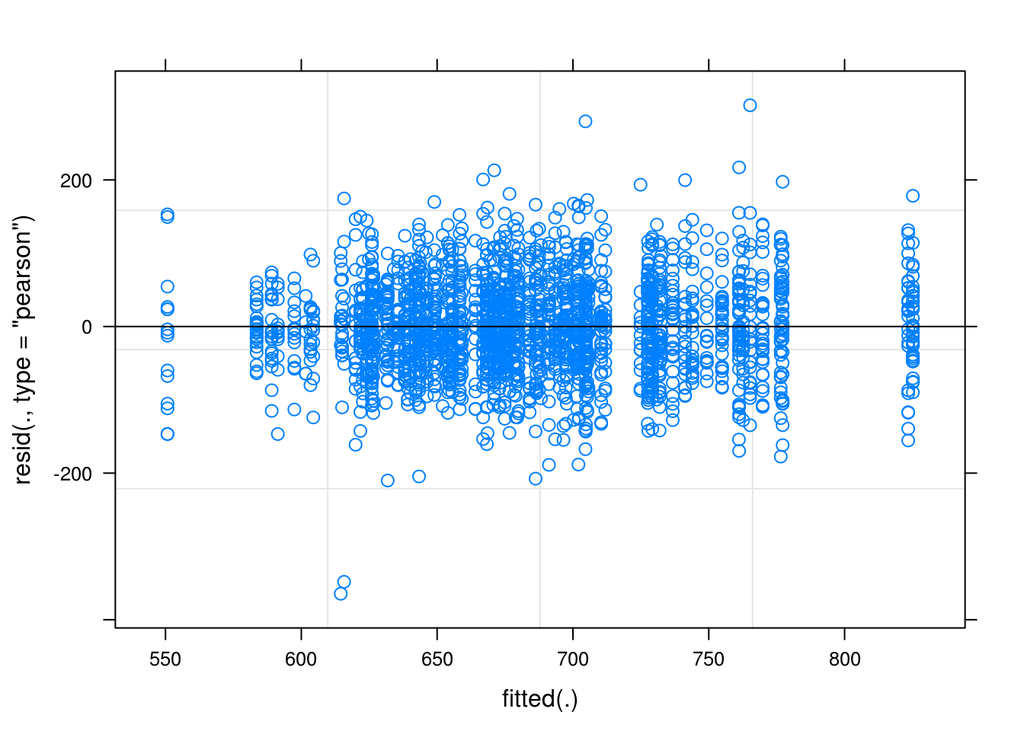

```r
plot(fit.lmer_full_fact_nest)
```

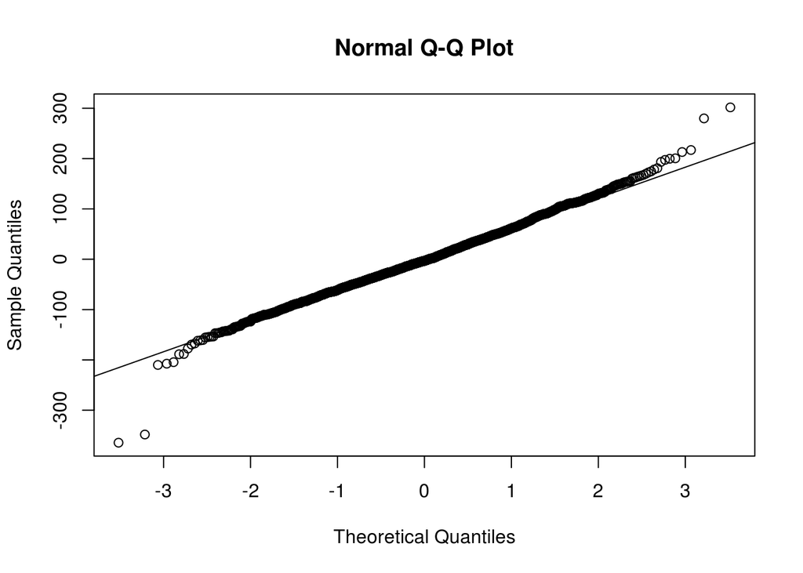

```r
m <- fit.lmer_full_fact_nest
qqnorm(residuals(m)); qqline(residuals(m));
```

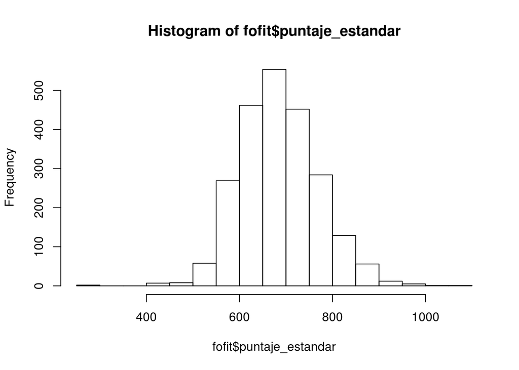

```r
hist(fofit$puntaje_estandar)
```